# TP statistiques bivariées

26 février 2026

## Comptages

## Données

[Enquête de vie 2003](https://www.insee.fr/fr/statistiques/2532244) de l’INSEE

```r
library("questionr")
data(hdv2003)
```

## Tableaux de contingence

Tableau croisé de comptage.

```r
(tab_x <- table(hdv2003$sexe, hdv2003$cuisine))
```

```
##
##         Non Oui
##   Homme 629 270
##   Femme 490 611
```

## Test du \(chi^2\)

Test de l’indépendance des lignes et des colonnes.

Hypothèse nulle : la fréquence relative de chaque cellule du tableau est le produit des fréquences marginales.

```r
n <- sum(tab_x)
sexe_f <- rowSums(tab_x) / n
cuisine_f <- colSums(tab_x) / n
outer(sexe_f, cuisine_f, `*`) * n
```

```
##            Non      Oui
## Homme 502.9905 396.0095
## Femme 616.0095 484.9905
```

La somme des carrés des écarts des effectifs divisés par la valeur attendue suit une loi du \(\chi_2\) à \((I -1) \times (J - 1)\) degrés de liberté (I et J sont les nombres de lignes et colonnes)

## Test du \(chi^2\)

```r
chisq.test(tab_x)
```

```
##
##  Pearson's Chi-squared test with Yates'
##  continuity correction
##
## data:  tab_x
## X-squared = 129.15, df = 1, p-value <
## 2.2e-16
```

Les écarts sont significatifs avec une p-value proche de 0.

## Graphique

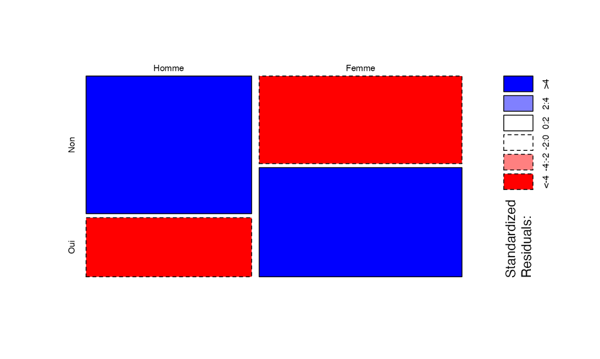

```r
mosaicplot(tab_x, shade = TRUE, main = "")
```

L’argument `shade = TRUE` affiche les résidus du test qui [suivent approximativement une loi normale centrée réduite](https://www.normalesup.org/~carpenti/Notes/Khi2-Contingence/Chi-2-et-Residus.pdf) (la valeur critique 2 correspond à 95% de confiance).

## Variables continues

## Covariance

La covariance entre \(X\) et \(Y\), deux variables aléatoires, est \[\mathrm{Cov}(X, Y) = \mathbb{E}[(X - \mathbb{E}(X))(Y - \mathbb{E}(Y))]\] donc \[\mathrm{var}(X) = \mathrm{Cov}(X, X)\]

Empiriquement : \[\hat{\mathrm{Cov}}(X, Y) = \frac{1}{n - 1}\sum_i{(x_i - \bar{x})(y_i - \bar{y})}\]

## Estimation

Données Ventoux.

```r
read_csv2("data/Inv_GEEFT_Ventoux_09-2020.csv") |>
  rename(
    espece = Espèce,
    diametre = `Diamètre (cm)`,
    hauteur = `Hauteur réelle (m)`
  ) -> ventoux
```

La hauteur des arbres covarie positivement avec le diamètre.

```r
with(ventoux, cov(hauteur, diametre))
```

```
## [1] 75.31186
```

## Corrélation de Pearson

Pour simplifier l’interprétation, on normalise la covariance par le produit des écarts-types :

\[\mathrm{Cor}(X, Y) = \frac{\mathrm{Cov}(X, Y)}{\sqrt{(\mathrm{var}(X)\mathrm{var}(Y))}}\] Donc \(\mathrm{Cor}(X, X) = 1\) et \(\mathrm{Cor}(X, -X) = -1\).

La corrélation est comprise entre -1 et 1.

```r
with(ventoux, cor(hauteur, diametre))
```

```
## [1] 0.8427001
```

Les données sont très corrélées (le test viendra plus tard).

## Corrélation de Spearman

Les valeurs des données sont remplacées par leurs rangs.

```r
with(ventoux, cor(hauteur, diametre, method = "spearman"))
```

```
## [1] 0.8490534
```

Remarquer la proximité des valeurs.